# MLE&MAP3

LinyiGuo

2019/10/6

# Grid search

Grid search is to calculate the MLE or MAP, which could avoid local minimum value.

**Likelihood & Loglikelihood**

```r
# define likelihood function

likelihood <- function(theta, Trend, Season, Obs){
  n <- length(Obs)
  a <- 0
  for (i in 12:n)  a <- a + (sum(Season[(i-11):i]))^2
  L <- (1/sqrt(2*pi*prod(theta)))^n *
          exp(-sum((Obs - Trend - Season)^2)/(2*theta[1])) *
          exp(-sum((Trend[-1]-Trend[-n])^2)/(2*theta[2])) *
          exp(- a/(2*theta[3]))
  return(L)
}


# loglikelihood
loglikelihood <- function(theta, Trend, Season, Obs ){
  n <- length(Obs)
  a <- 0
  for (i in 12:n)  a <- a + (sum(Season[(i-11):i]))^2
  l <- (-n/2) * log(theta[1]) - n/2 * log(theta[2]) - n/2 * log(theta[3]) -
    sum((Obs-Trend-Season)^2)/(2*theta[1]) -
    sum((Trend[-1]-Trend[-n])^2)/(2*theta[2]) -
    a / (2*theta[3])
  return(l)
}
```

## Grid Search for Single Parameter

Here, I fix two variances at **1** and let the other one is a sequence with 10000 points.

1. variances in observation function are $0.001,0.002, \dots , 10$
2. variances in trend function are $0.01,0.02, \dots , 100$
3. variances in seasonal function are $0.01,0.02, \dots , 100$

### MLE

This is my code for related function:

```r
# define a 'large' function to return the loglikelihood series of one single parameter's sequence
loglikelihood_single_gs <- function(data, type){
  if(type == 1) {
    l1 <- c()
    for (i in 1:10000){
      ssm <- SSModel(data ~ SSMtrend(1, Q=list(1)) +
                       SSMseasonal(12, sea.type = 'dummy', Q=1), H=i*0.001)
      mod <- KFS(ssm)
      Trend <- coef(mod, states = 'trend')
      Season <- rowSums(coef(mod, states = 'seasonal'))
      theta <- c(i*0.001,1,1)
      l1 <- c(l1, loglikelihood(theta=theta, Trend=Trend, Season=Season, Obs = data))
    }
    return(l1)
  }

  if(type == 2){
    l2 <- c()
    for (i in 1:10000){
      ssm <- SSModel(data ~ SSMtrend(1, Q=list(i*0.01)) +
                       SSMseasonal(12, sea.type = 'dummy', Q=1), H=1)
      mod <- KFS(ssm)
      Trend <- coef(mod, states = 'trend')
      Season <- rowSums(coef(mod, states = 'seasonal'))
      theta <- c(1,i*0.01,1)
      l2 <- c(l2, loglikelihood(theta=theta, Trend=Trend, Season=Season, Obs = data))
    }
    return(l2)
  }

  if(type == 3){
    l3 <- c()
    for (i in 1:10000){
      ssm <- SSModel(data ~ SSMtrend(1, Q=list(1)) +
                       SSMseasonal(12, sea.type = 'dummy', Q=i*0.01), H=1)
      mod <- KFS(ssm)
      Trend <- coef(mod, states = 'trend')
      Season <- rowSums(coef(mod, states = 'seasonal'))
      theta <- c(1,1,i*0.01)
      l3 <- c(l3, loglikelihood(theta=theta, Trend=Trend, Season=Season, Obs = data))
    }
    return(l3)
  }
}
```

**For the likelihood curve**

Here, the only difference from the function *loglikelihood_single_gs* is that we apply likelihood instead of loglikelihood defined at beginning.

```r
# define a 'large' function to return the loglikelihood series of one single parameter's sequence
likelihood_single_gs <- function(data, type){
  if(type == 1) {
    L1 <- c()
    for (i in 1:10000){
      ssm <- SSModel(data ~ SSMtrend(1, Q=list(1)) +
                       SSMseasonal(12, sea.type = 'dummy', Q=1), H=i*0.001)
      mod <- KFS(ssm)
      Trend <- coef(mod, states = 'trend')
      Season <- rowSums(coef(mod, states = 'seasonal'))
      theta <- c(i*0.001,1,1)
      L1 <- c(L1, likelihood(theta=theta, Trend=Trend, Season=Season, Obs = data))
    }
    return(L1)
  }

  if(type == 2){
    L2 <- c()
    for (i in 1:10000){
      ssm <- SSModel(data ~ SSMtrend(1, Q=list(i*0.01)) +
                       SSMseasonal(12, sea.type = 'dummy', Q=1), H=1)
      mod <- KFS(ssm)
      Trend <- coef(mod, states = 'trend')
      Season <- rowSums(coef(mod, states = 'seasonal'))
      theta <- c(1,i*0.01,1)
      L2 <- c(L2, likelihood(theta=theta, Trend=Trend, Season=Season, Obs = data))
    }
    return(L2)
  }

  if(type == 3){
    L3 <- c()
    for (i in 1:10000){
      ssm <- SSModel(data ~ SSMtrend(1, Q=list(1)) +
                       SSMseasonal(12, sea.type = 'dummy', Q=i*0.01), H=1)
      mod <- KFS(ssm)
      Trend <- coef(mod, states = 'trend')
      Season <- rowSums(coef(mod, states = 'seasonal'))
      theta <- c(1,1,i*0.01)
      L3 <- c(L3, likelihood(theta=theta, Trend=Trend, Season=Season, Obs = data))
    }
    return(L3)
  }
}
```

The loglikelihood curves:

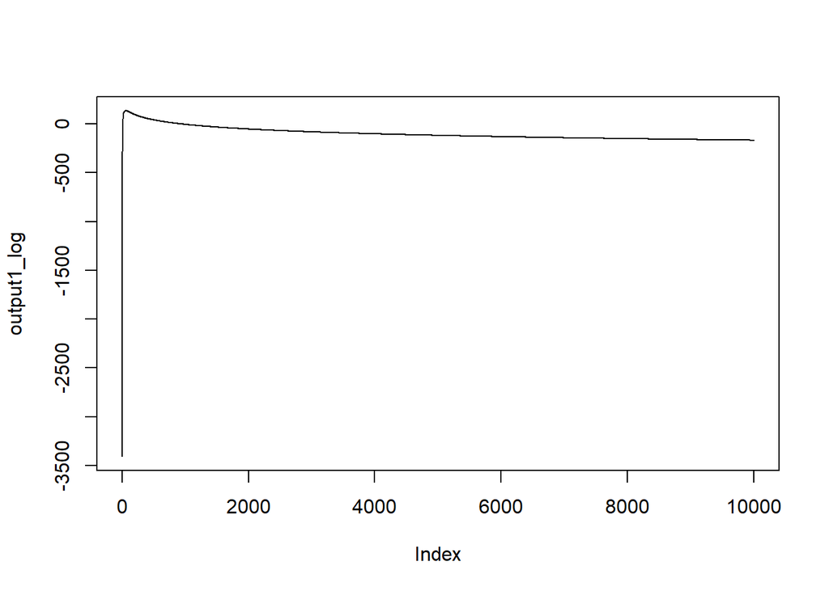

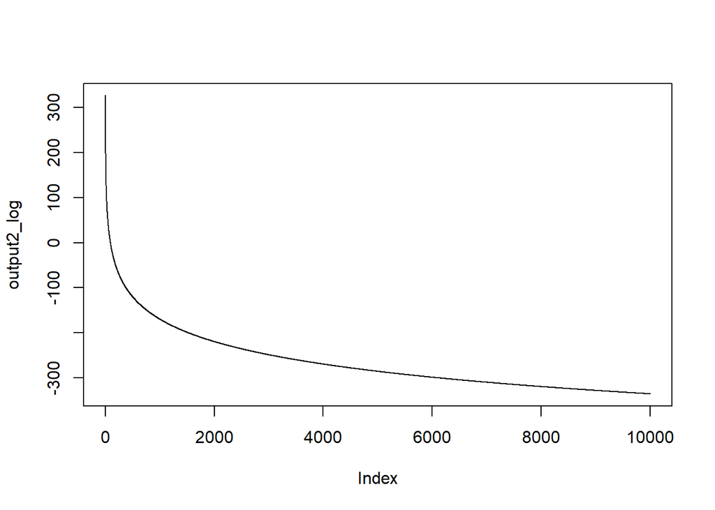

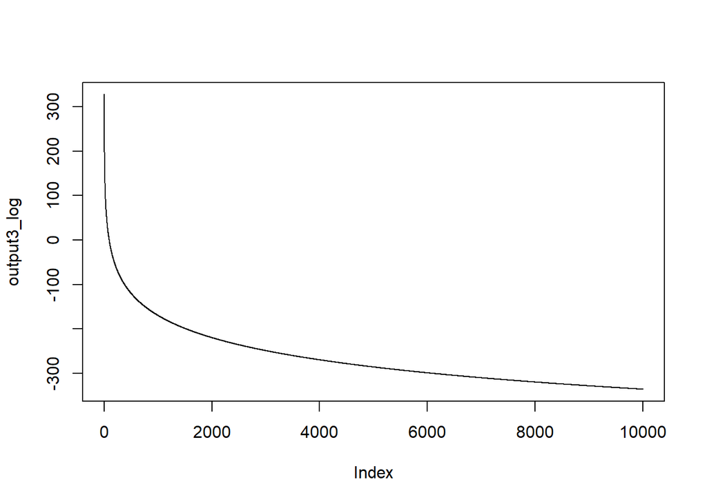

The likelihood curves:

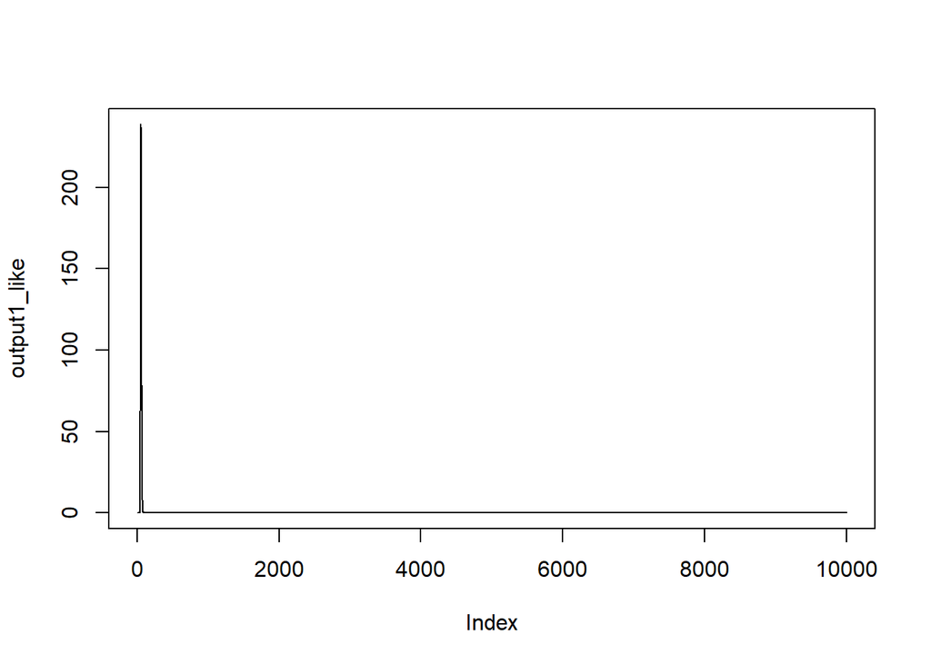

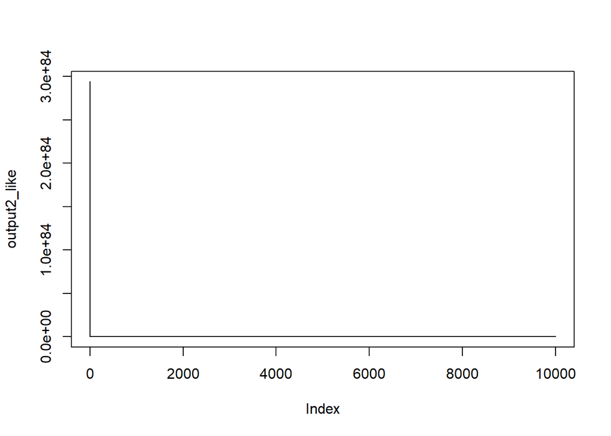

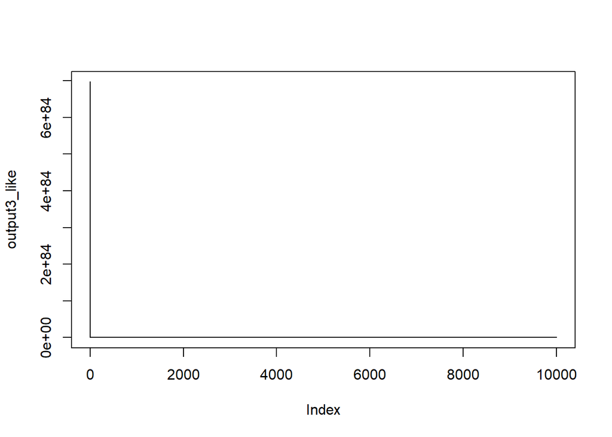

I take a look at the first few points specially since there is a change at the beginning:

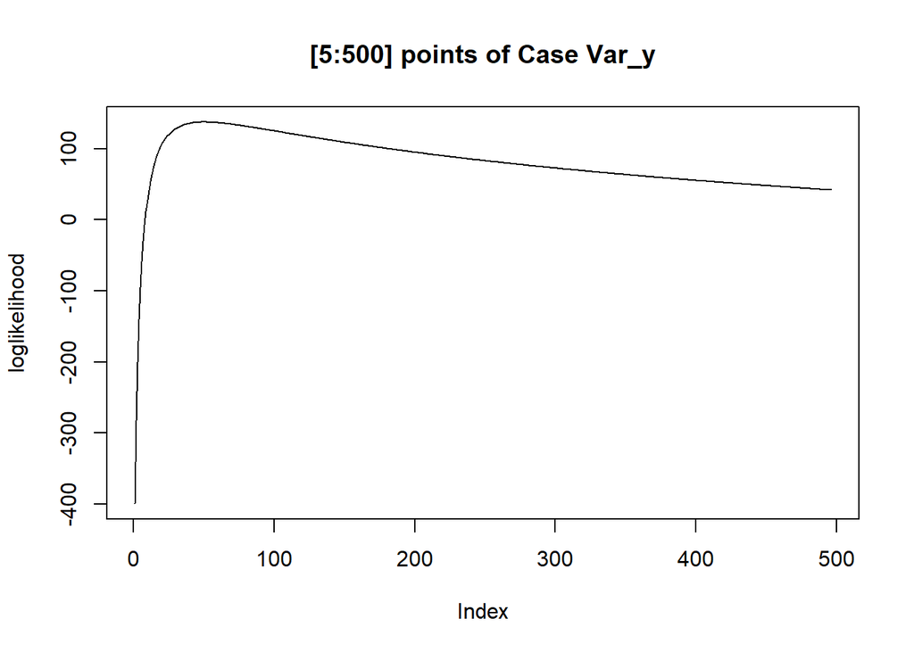

```r
plot(output1_log[5:500], type = 'l',
     main = '[5:500] points of Case Var_y', ylab = 'loglikelihood')
```

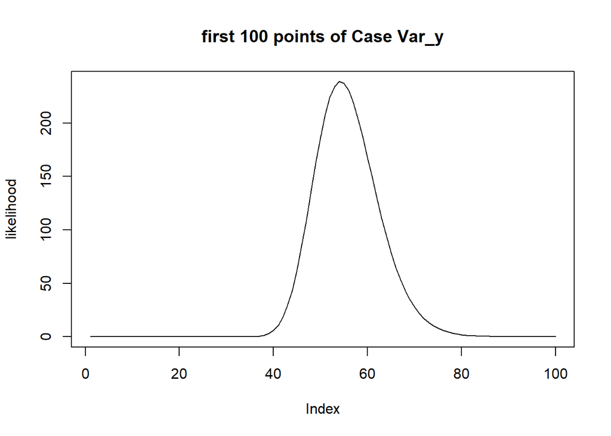

```r
plot(output1_like[1:100], type = 'l',
     main = 'first 100 points of Case Var_y', ylab = 'likelihood')
```

### MAP

Because our paramters are variances, that is to say they are greater than 0, so the priors on them should be some distribution that is defined on $(0,\infty)$.

**Prior**

```r
# if we let prior is standard exponential function
prior <- function(x) exp(-x)
```

**Posterior/MAP**

It is similar to the likelihood function but we times the prior:

```r
posterior_single_gs <- function(data, type) {

  if(type == 1){
    map1 <- c()
   for (i in 1:10000) {
     ssm <- SSModel(data ~ SSMtrend(1, Q=list(1)) +
                      SSMseasonal(12, sea.type = 'dummy', Q = 1 ), H = i*0.001)
     mod <- KFS(ssm)
     Trend <- coef(mod, states = 'trend')
     Season <- rowSums(coef(mod, states = 'seasonal'))
     theta <- c(i*0.001,1,1)
     map <- likelihood(theta=theta,Trend=Trend,Season=Season,Obs = data) *
       prior(theta[type])
     map1 <- c(map1, map)
   }
    return(map1)
  }

  if(type == 2){
    map2 <- c()
   for (i in 1:10000) {
     ssm <- SSModel(data ~ SSMtrend(1, Q=list(0.01*i)) +
                      SSMseasonal(12, sea.type = 'dummy', Q = 1 ), H = 1)
     mod <- KFS(ssm)
     Trend <- coef(mod, states = 'trend')
     Season <- rowSums(coef(mod, states = 'seasonal'))
     theta <- c(1,i*0.01,1)
     map <- likelihood(theta=theta,Trend=Trend,Season=Season,Obs = data) *
       prior(theta[type])
     map2 <- c(map2, map)
   }
    return(map2)
  }

  if(type == 3){
    map3 <- c()
   for (i in 1:10000) {
     ssm <- SSModel(data ~ SSMtrend(1, Q=list(1)) +
                      SSMseasonal(12, sea.type = 'dummy', Q = 0.01*i ), H = 1)
     mod <- KFS(ssm)
     Trend <- coef(mod, states = 'trend')
     Season <- rowSums(coef(mod, states = 'seasonal'))
     theta <- c(1,1,0.01*i)
     map <- likelihood(theta=theta,Trend=Trend,Season=Season,Obs = data) *
       prior(theta[type])
     map3 <- c(map3, map)
   }
    return(map3)
  }
}
```

Then these are the posterior curves:(still on AirPassengers)

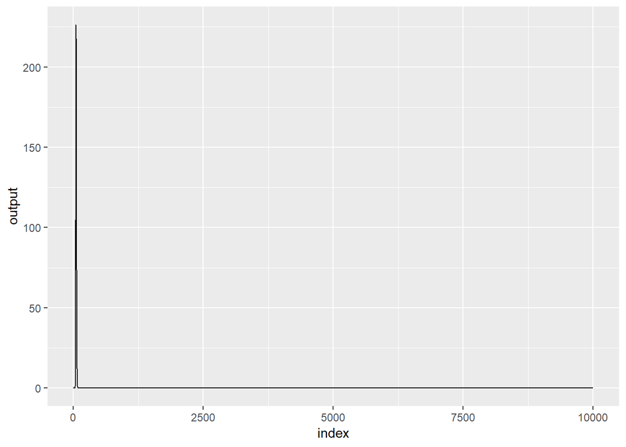

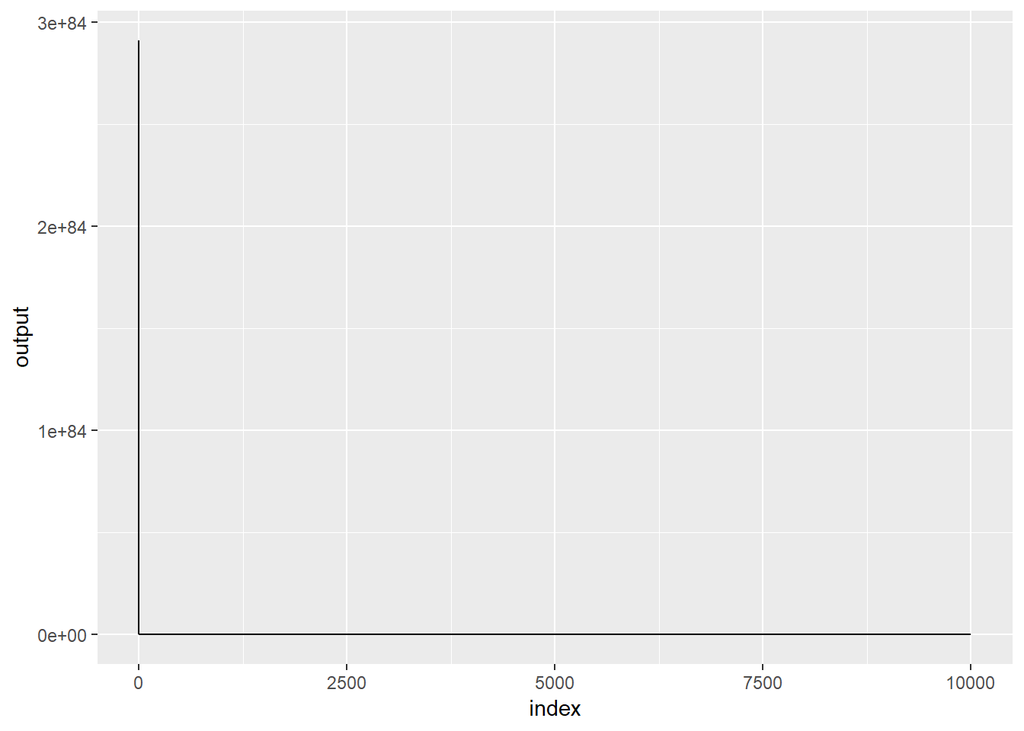

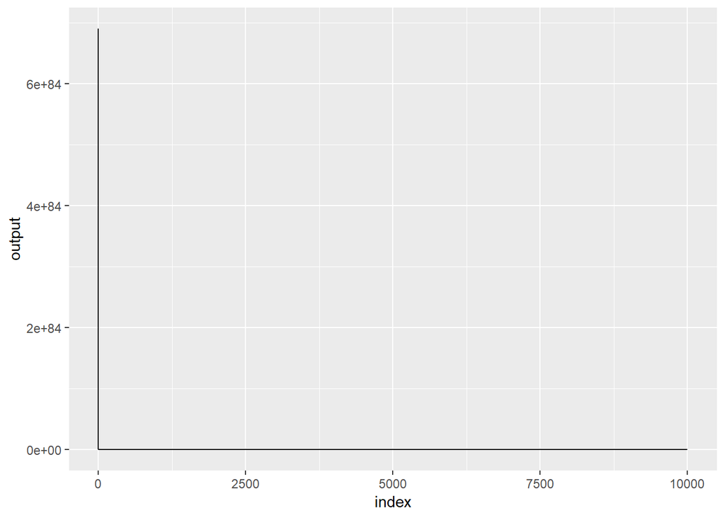

Let’t take a look at the first 100 points of likelihood, prior and posterior curves at the same time(Fixed $\sigma_T^2, \sigma_S^2$ and $\sigma_y^2=0.001,0.002,\dots, 10$):

**Orange: Likelihood ； Red: Prior ； Blue: Posterior**

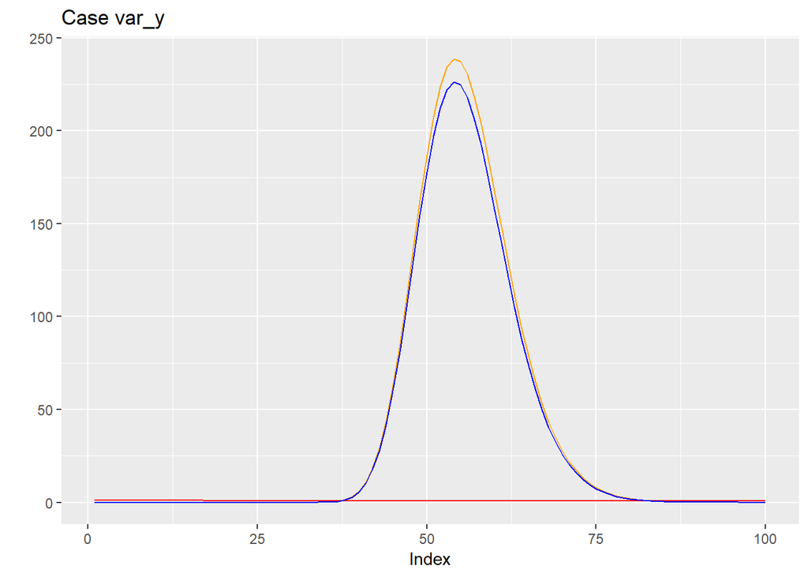

*Note: The prior curve is not a horizontal line actually.*

**If we change the prior to a generic exponential distribution**

```r
prior <- function(x, lambda) lambda * exp(-lambda * x)
```

**Update the posterior**(hide code)

We let lambda = 100:

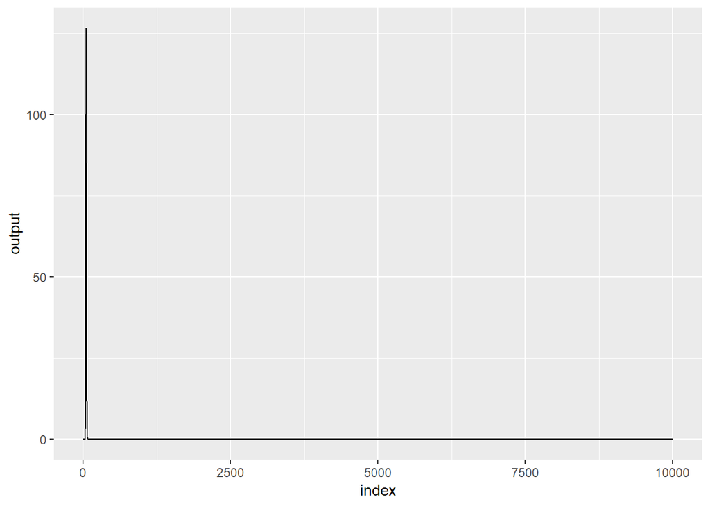

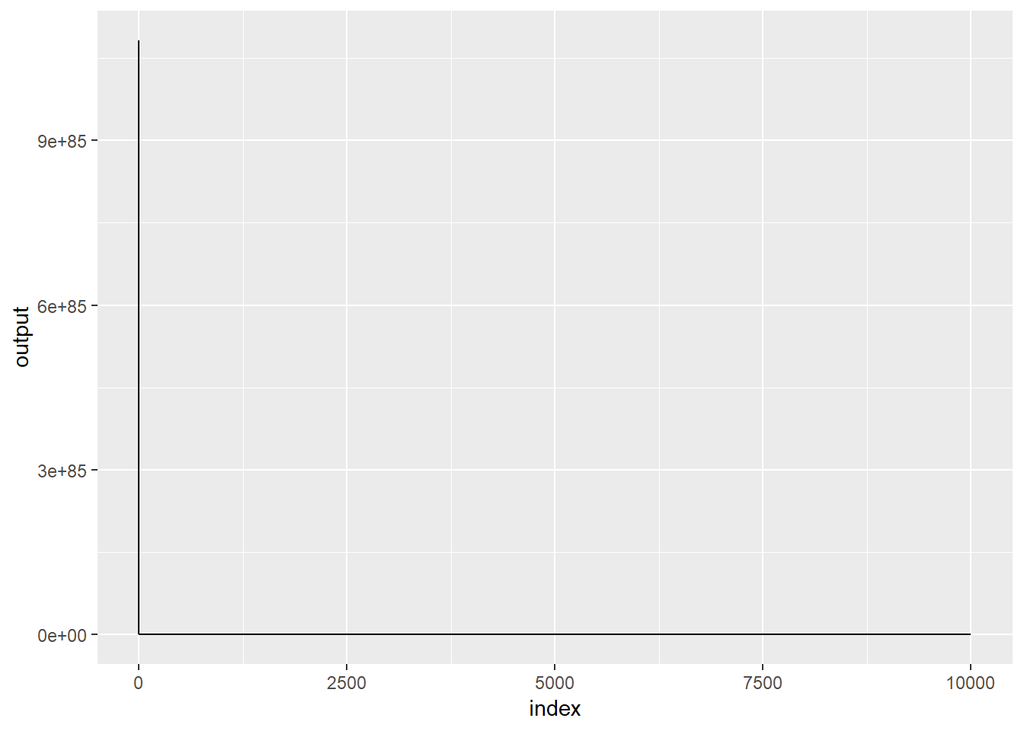

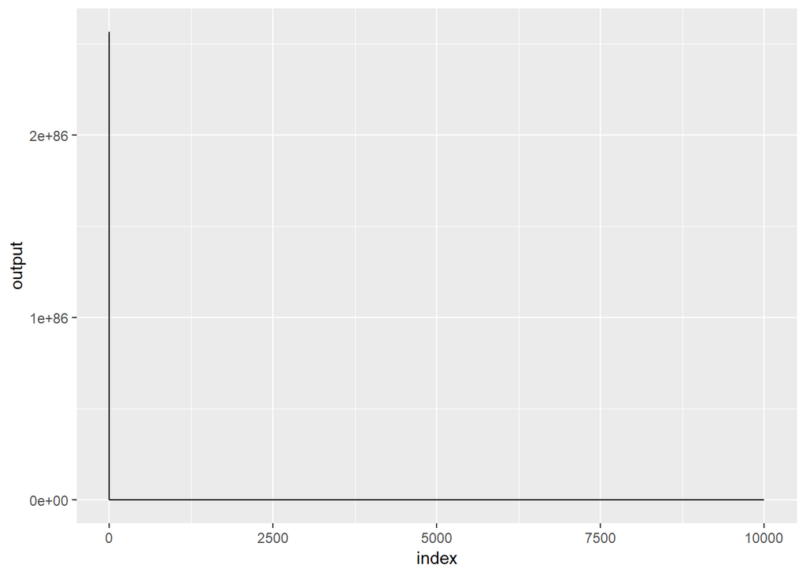

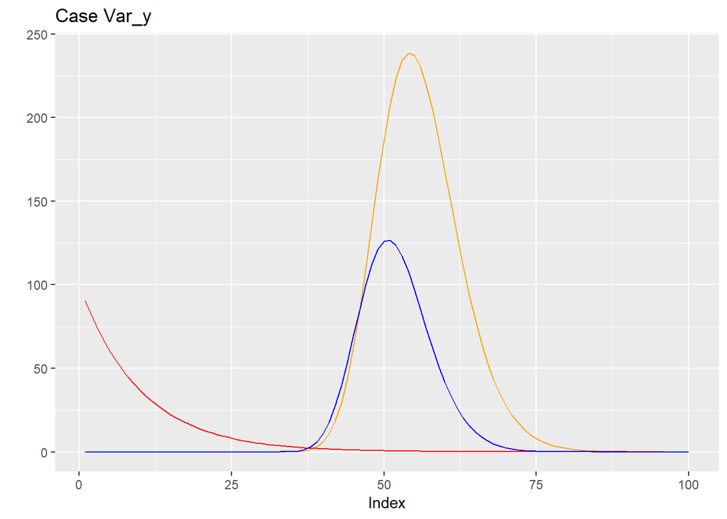

```r
# var_y
ggplot(data.frame(output1_like=output1_like[1:100],
                  output1_prior=prior(seq(0.001,10,0.001),lambda)[1:100],
                  output1_post=output1_post[1:100],
                  index=c(1:100))) +
  geom_line(aes(y=output1_like, x=index),color='orange') +
  geom_line(aes(y=output1_prior, x=index), color='red') +
  geom_line(aes(y=output1_post, x=index),color='blue') +
  labs(title = 'Case Var_y', x='Index', y='')
```

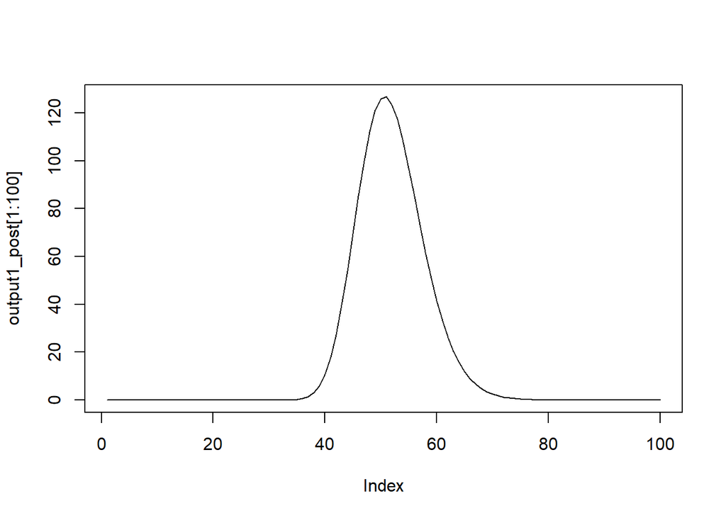

```r
plot(output1_post[1:100], type = 'l')
```

```r
which.max(output1_post)
```

```
## [1] 51
```

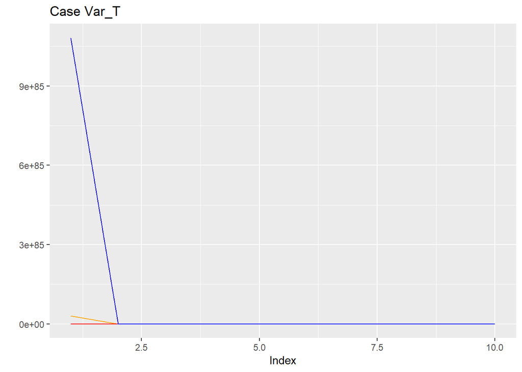

```r
# var_T

ggplot(data.frame(output2_like=output2_like[1:10],
                  output2_prior=prior(seq(0.01,100,0.01),lambda)[1:10],
                  output2_post=output2_post[1:10],
                  index=c(1:10))) +
  geom_line(aes(y=output2_like, x=index),color='orange') +
  geom_line(aes(y=output2_prior, x=index), color='red') +
  geom_line(aes(y=output2_post, x=index),color='blue') +
  labs(title = 'Case Var_T', x='Index', y='')
```

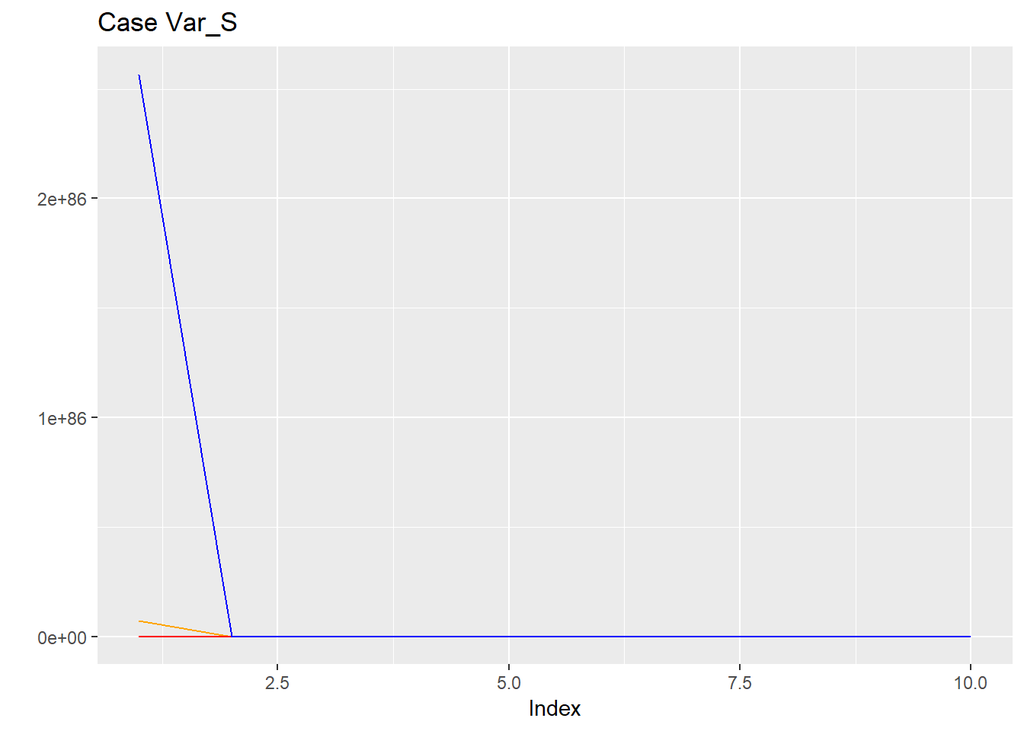

```r
# var_S
ggplot(data.frame(output3_like=output3_like[1:10],
                  output3_prior=prior(seq(0.01,100,0.01),lambda)[1:10],
                  output3_post=output3_post[1:10],
                  index=c(1:10))) +
  geom_line(aes(y=output3_like, x=index),color='orange') +
  geom_line(aes(y=output3_prior, x=index), color='red') +
  geom_line(aes(y=output3_post, x=index),color='blue') +
  labs(title = 'Case Var_S', x='Index', y='')
```

**Again, Orange: Likelihood ； Red: Prior ； Blue: Posterior**